# Factors Leading to Employee Attrition

DDS_6306

Jason Rupp

6 Dec 19

# Introduction

DDSAnalytics is an analytics company that specializes in talent management solutions for Fortune 100 companies. Talent management is defined as the iterative process of developing and retaining employees. It may include workforce planning, employee training programs, identifying high-potential employees and reducing/preventing voluntary employee turnover (attrition). To gain a competitive edge over its competition, DDSAnalytics is planning to leverage data science for talent management. The executive leadership has identified predicting employee turnover as its first application of data science for talent management. Before the business green lights the project, they have tasked your data science team to conduct an analysis of existing employee data.

I have been given a dataset of employee data to analyize to identify factors that lead to attrition. The top three factors that contribute to turnover will be identified backed up by evidence provided by analysis. In addition a model will be built to predict attrition, and a model to predict employee salary.

Install/Load Libraries

```r
library(plyr)
library(tidyverse)
library(naniar)
library(caret)
library(e1071)
library(mlbench)
library(fastDummies)
library(xgboost)
library(class)
library(mlr)
library(gridExtra)
library(corrplot)
library(reshape2)
```

# Exploratory Data Analysis

### Load Data

```r
# Read the data with attrition and salaries

raw_df <- read.csv("data/CaseStudy2-data.csv")

# Summary Stats of Dataframe

dim(raw_df)
```

```
## [1] 870  36
```

```r
names(raw_df)
```

```
##  [1] "ID"                       "Age"
##  [3] "Attrition"                "BusinessTravel"
##  [5] "DailyRate"                "Department"
##  [7] "DistanceFromHome"         "Education"
##  [9] "EducationField"           "EmployeeCount"
## [11] "EmployeeNumber"           "EnvironmentSatisfaction"
## [13] "Gender"                   "HourlyRate"
## [15] "JobInvolvement"           "JobLevel"
## [17] "JobRole"                  "JobSatisfaction"
## [19] "MaritalStatus"            "MonthlyIncome"
## [21] "MonthlyRate"              "NumCompaniesWorked"
## [23] "Over18"                   "OverTime"
## [25] "PercentSalaryHike"        "PerformanceRating"
## [27] "RelationshipSatisfaction" "StandardHours"
## [29] "StockOptionLevel"         "TotalWorkingYears"
## [31] "TrainingTimesLastYear"    "WorkLifeBalance"
## [33] "YearsAtCompany"           "YearsInCurrentRole"
## [35] "YearsSinceLastPromotion"  "YearsWithCurrManager"
```

```r
summary(raw_df)
```

```
##        ID             Age        Attrition           BusinessTravel
##  Min.   :  1.0   Min.   :18.00   No :730   Non-Travel       : 94
##  1st Qu.:218.2   1st Qu.:30.00   Yes:140   Travel_Frequently:158
##  Median :435.5   Median :35.00             Travel_Rarely    :618
##  Mean   :435.5   Mean   :36.83
##  3rd Qu.:652.8   3rd Qu.:43.00
##  Max.   :870.0   Max.   :60.00
##
##    DailyRate                       Department  DistanceFromHome
##  Min.   : 103.0   Human Resources       : 35   Min.   : 1.000
##  1st Qu.: 472.5   Research & Development:562   1st Qu.: 2.000
##  Median : 817.5   Sales                 :273   Median : 7.000
##  Mean   : 815.2                                Mean   : 9.339
##  3rd Qu.:1165.8                                3rd Qu.:14.000
##  Max.   :1499.0                                Max.   :29.000
##
##    Education              EducationField EmployeeCount EmployeeNumber
##  Min.   :1.000   Human Resources : 15    Min.   :1     Min.   :   1.0
##  1st Qu.:2.000   Life Sciences   :358    1st Qu.:1     1st Qu.: 477.2
##  Median :3.000   Marketing       :100    Median :1     Median :1039.0
##  Mean   :2.901   Medical         :270    Mean   :1     Mean   :1029.8
##  3rd Qu.:4.000   Other           : 52    3rd Qu.:1     3rd Qu.:1561.5
##  Max.   :5.000   Technical Degree: 75    Max.   :1     Max.   :2064.0
##
##  EnvironmentSatisfaction    Gender      HourlyRate     JobInvolvement
##  Min.   :1.000           Female:354   Min.   : 30.00   Min.   :1.000
##  1st Qu.:2.000           Male  :516   1st Qu.: 48.00   1st Qu.:2.000
##  Median :3.000                        Median : 66.00   Median :3.000
##  Mean   :2.701                        Mean   : 65.61   Mean   :2.723
##  3rd Qu.:4.000                        3rd Qu.: 83.00   3rd Qu.:3.000
##  Max.   :4.000                        Max.   :100.00   Max.   :4.000
##
##     JobLevel                          JobRole    JobSatisfaction
##  Min.   :1.000   Sales Executive          :200   Min.   :1.000
##  1st Qu.:1.000   Research Scientist       :172   1st Qu.:2.000
##  Median :2.000   Laboratory Technician    :153   Median :3.000
##  Mean   :2.039   Manufacturing Director   : 87   Mean   :2.709
##  3rd Qu.:3.000   Healthcare Representative: 76   3rd Qu.:4.000
##  Max.   :5.000   Sales Representative     : 53   Max.   :4.000
##                  (Other)                  :129
```

[output cut: 25 more lines]

```
##  Min.   :1.000   Min.   : 0.000   Min.   : 0.000
##  1st Qu.:2.000   1st Qu.: 3.000   1st Qu.: 2.000
##  Median :3.000   Median : 5.000   Median : 3.000
##  Mean   :2.782   Mean   : 6.962   Mean   : 4.205
##  3rd Qu.:3.000   3rd Qu.:10.000   3rd Qu.: 7.000
##  Max.   :4.000   Max.   :40.000   Max.   :18.000
##
##  YearsSinceLastPromotion YearsWithCurrManager
##  Min.   : 0.000          Min.   : 0.00
##  1st Qu.: 0.000          1st Qu.: 2.00
##  Median : 1.000          Median : 3.00
##  Mean   : 2.169          Mean   : 4.14
##  3rd Qu.: 3.000          3rd Qu.: 7.00
##  Max.   :15.000          Max.   :17.00
##
```

#### Subsetting raw_df into Attrition groups

```r
# Employees w. Attrition

attr_df <- raw_df %>% filter(Attrition == "Yes")

# Employees w.o Atrrition

nttr_df <- raw_df %>% filter(Attrition == "No")

# Group Summaries to spot differences
summary(attr_df)
```

```
##        ID             Age        Attrition           BusinessTravel
##  Min.   : 28.0   Min.   :18.00   No :  0   Non-Travel       :11
##  1st Qu.:259.2   1st Qu.:28.00   Yes:140   Travel_Frequently:35
##  Median :485.5   Median :32.00             Travel_Rarely    :94
##  Mean   :462.6   Mean   :33.79
##  3rd Qu.:687.5   3rd Qu.:39.00
##  Max.   :863.0   Max.   :58.00
##
##    DailyRate                       Department DistanceFromHome
##  Min.   : 103.0   Human Resources       : 6   Min.   : 1.00
##  1st Qu.: 428.8   Research & Development:75   1st Qu.: 3.00
##  Median : 751.0   Sales                 :59   Median : 9.00
##  Mean   : 784.3                               Mean   :10.96
##  3rd Qu.:1110.8                               3rd Qu.:19.00
##  Max.   :1496.0                               Max.   :29.00
##
##    Education              EducationField EmployeeCount EmployeeNumber
##  Min.   :1.000   Human Resources : 4     Min.   :1     Min.   :   1.0
##  1st Qu.:2.000   Life Sciences   :53     1st Qu.:1     1st Qu.: 483.2
##  Median :3.000   Marketing       :20     Median :1     Median :1021.5
##  Mean   :2.786   Medical         :37     Mean   :1     Mean   : 998.4
##  3rd Qu.:3.250   Other           : 9     3rd Qu.:1     3rd Qu.:1508.5
##  Max.   :5.000   Technical Degree:17     Max.   :1     Max.   :2027.0
##
##  EnvironmentSatisfaction    Gender     HourlyRate     JobInvolvement
##  Min.   :1.000           Female:53   Min.   : 32.00   Min.   :1.000
##  1st Qu.:1.000           Male  :87   1st Qu.: 51.00   1st Qu.:2.000
##  Median :3.000                       Median : 68.50   Median :3.000
##  Mean   :2.507                       Mean   : 67.29   Mean   :2.421
##  3rd Qu.:4.000                       3rd Qu.: 84.00   3rd Qu.:3.000
##  Max.   :4.000                       Max.   :100.00   Max.   :4.000
##
##     JobLevel                          JobRole   JobSatisfaction
##  Min.   :1.000   Sales Executive          :33   Min.   :1.000
##  1st Qu.:1.000   Research Scientist       :32   1st Qu.:1.000
##  Median :1.000   Laboratory Technician    :30   Median :3.000
##  Mean   :1.636   Sales Representative     :24   Mean   :2.436
##  3rd Qu.:2.000   Healthcare Representative: 8   3rd Qu.:3.000
##  Max.   :5.000   Human Resources          : 6   Max.   :4.000
##                  (Other)                  : 7
```

[output cut: 25 more lines]

```
##  Min.   :1.000   Min.   : 0.000   Min.   : 0.000
##  1st Qu.:2.000   1st Qu.: 1.000   1st Qu.: 0.000
##  Median :3.000   Median : 3.000   Median : 2.000
##  Mean   :2.636   Mean   : 5.193   Mean   : 2.907
##  3rd Qu.:3.000   3rd Qu.: 8.000   3rd Qu.: 4.000
##  Max.   :4.000   Max.   :40.000   Max.   :15.000
##
##  YearsSinceLastPromotion YearsWithCurrManager
##  Min.   : 0.000          Min.   : 0.000
##  1st Qu.: 0.000          1st Qu.: 0.000
##  Median : 1.000          Median : 2.000
##  Mean   : 2.136          Mean   : 2.943
##  3rd Qu.: 2.000          3rd Qu.: 6.000
##  Max.   :15.000          Max.   :14.000
##
```

```r
summary(nttr_df)
```

```
##        ID             Age        Attrition           BusinessTravel
##  Min.   :  1.0   Min.   :18.00   No :730   Non-Travel       : 83
##  1st Qu.:213.2   1st Qu.:31.00   Yes:  0   Travel_Frequently:123
##  Median :425.5   Median :36.00             Travel_Rarely    :524
##  Mean   :430.3   Mean   :37.41
##  3rd Qu.:645.2   3rd Qu.:43.00
##  Max.   :870.0   Max.   :60.00
##
##    DailyRate                       Department  DistanceFromHome
##  Min.   : 111.0   Human Resources       : 29   Min.   : 1.000
##  1st Qu.: 483.8   Research & Development:487   1st Qu.: 2.000
##  Median : 828.5   Sales                 :214   Median : 7.000
##  Mean   : 821.2                                Mean   : 9.029
##  3rd Qu.:1178.2                                3rd Qu.:13.000
##  Max.   :1499.0                                Max.   :29.000
##
##    Education              EducationField EmployeeCount EmployeeNumber
##  Min.   :1.000   Human Resources : 11    Min.   :1     Min.   :  11.0
##  1st Qu.:2.000   Life Sciences   :305    1st Qu.:1     1st Qu.: 476.2
##  Median :3.000   Marketing       : 80    Median :1     Median :1049.5
##  Mean   :2.923   Medical         :233    Mean   :1     Mean   :1035.9
##  3rd Qu.:4.000   Other           : 43    3rd Qu.:1     3rd Qu.:1571.5
##  Max.   :5.000   Technical Degree: 58    Max.   :1     Max.   :2064.0
##
##  EnvironmentSatisfaction    Gender      HourlyRate     JobInvolvement
##  Min.   :1.000           Female:301   Min.   : 30.00   Min.   :1.000
##  1st Qu.:2.000           Male  :429   1st Qu.: 48.00   1st Qu.:2.000
##  Median :3.000                        Median : 64.50   Median :3.000
##  Mean   :2.738                        Mean   : 65.29   Mean   :2.781
##  3rd Qu.:4.000                        3rd Qu.: 82.75   3rd Qu.:3.000
##  Max.   :4.000                        Max.   :100.00   Max.   :4.000
##
##     JobLevel                          JobRole    JobSatisfaction
##  Min.   :1.000   Sales Executive          :167   Min.   :1.000
##  1st Qu.:1.000   Research Scientist       :140   1st Qu.:2.000
##  Median :2.000   Laboratory Technician    :123   Median :3.000
##  Mean   :2.116   Manufacturing Director   : 85   Mean   :2.762
##  3rd Qu.:3.000   Healthcare Representative: 68   3rd Qu.:4.000
##  Max.   :5.000   Research Director        : 50   Max.   :4.000
##                  (Other)                  : 97
```

[output cut: 25 more lines]

```
##  Min.   :1.00    Min.   : 0.000   Min.   : 0.000
##  1st Qu.:2.00    1st Qu.: 3.000   1st Qu.: 2.000
##  Median :3.00    Median : 6.000   Median : 3.000
##  Mean   :2.81    Mean   : 7.301   Mean   : 4.453
##  3rd Qu.:3.00    3rd Qu.:10.000   3rd Qu.: 7.000
##  Max.   :4.00    Max.   :33.000   Max.   :18.000
##
##  YearsSinceLastPromotion YearsWithCurrManager
##  Min.   : 0.000          Min.   : 0.00
##  1st Qu.: 0.000          1st Qu.: 2.00
##  Median : 1.000          Median : 3.00
##  Mean   : 2.175          Mean   : 4.37
##  3rd Qu.: 3.000          3rd Qu.: 7.00
##  Max.   :15.000          Max.   :17.00
##
```

### Check for missing values in the dataset

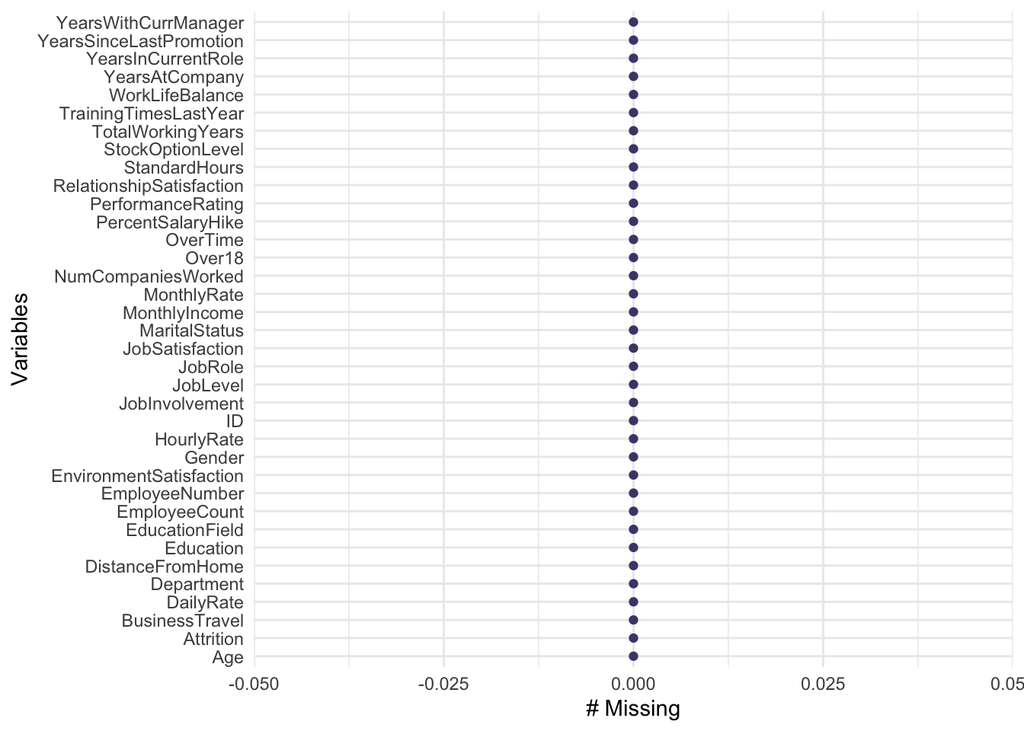

- No missing values in the primary dataset.

### Company Data Exploration

We would like to visualize some data to get a general idea about this company.

*The follow visualizations will represent the data from the primary dataset which was provided, the “Comp” datasets were not included in this EDA*

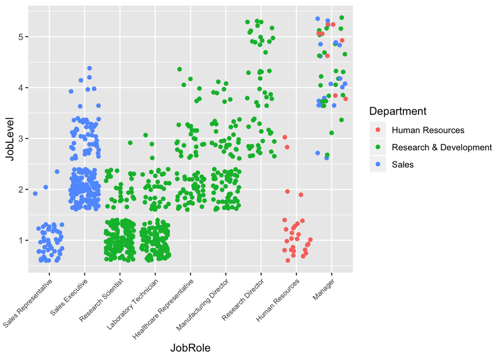

The company is comprised of three departments as listed above, the departments were grouped to visualize professional growth through the company

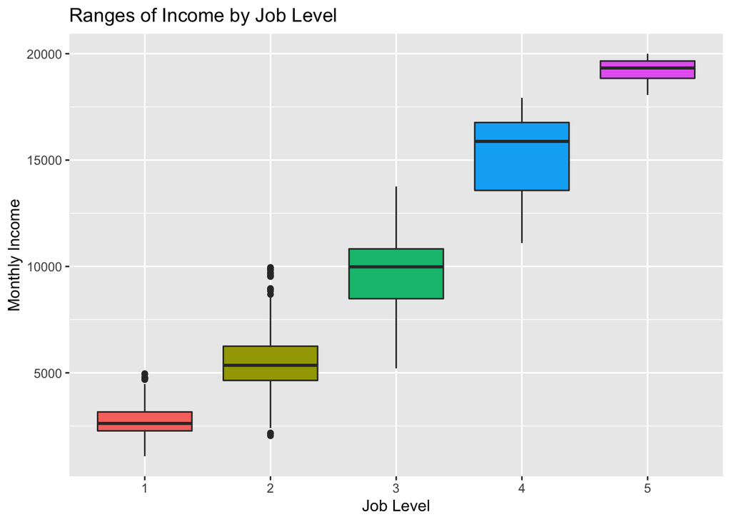

There is a postive correlation between job level and monthly income. A higher monthly income *may* decrease the chance of an employee’s separation from the company, further analysis to follow.

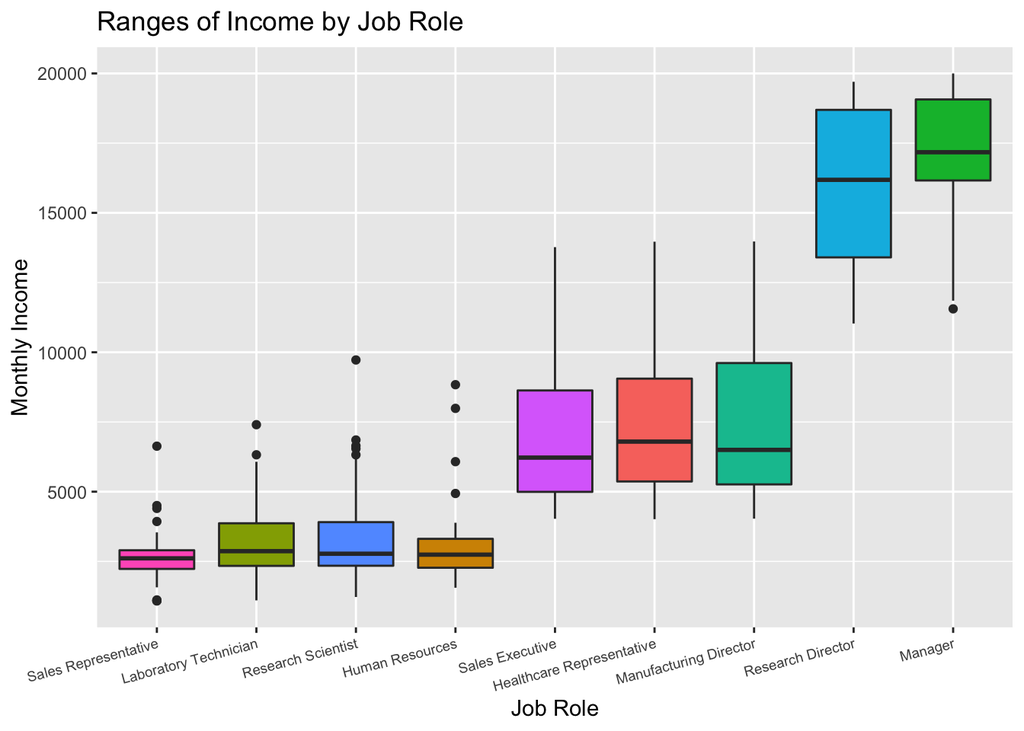

This is supporting the point of income being tied to a specific job role/level. If a higher monthly income is a professional goal for an employee, harnessing an environment in which they feel like they can achieve this would likely lead to this person remaining with the company.

Note on Monthly income: It is difficult to use monthly income as a determining factor for why an employee will remain with a company, as we have no “market value” to compare. This company could pay 25% more than all competitors with excellent benefits, and with the given data there is no means to support this evidence. The analysis will proceed with the assumption that the company pays market value for the level of talent. Additionally, a model will be developed to determine what the value for an employee is in terms of monthly salary to leverage with salary negotiations.

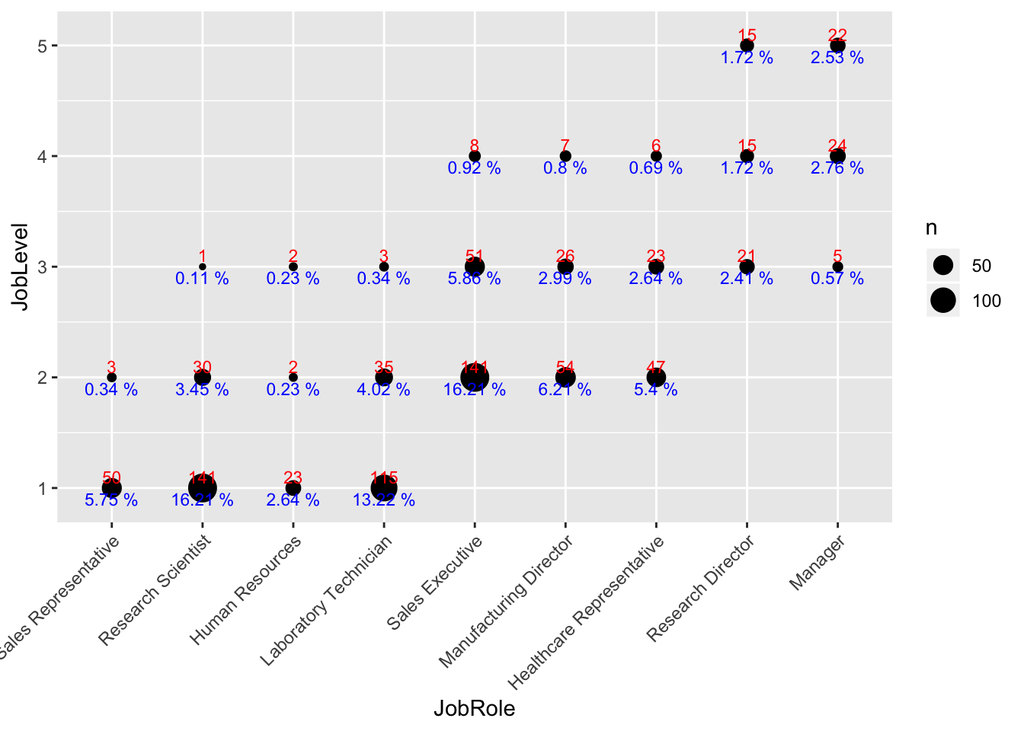

```r
raw_df %>%
  ggplot(aes(x=JobRole, y=JobLevel)) +
  geom_count() + scale_x_discrete(limits = ord) +
  geom_text(data = df_count,
    aes(df_count$JobRole,
        df_count$JobLevel,
        label = df_count$n),
    size = 3,
    nudge_y = 0.1,
    color = 'red') +
  geom_text(data = df_count,
    aes(df_count$JobRole,
        df_count$JobLevel,
        label = paste(df_count$prop, "%")),
    size = 3,
    nudge_y = -0.1,
    color = 'blue') +
  theme(axis.text.x = element_text(angle=45, hjust = 1))
```

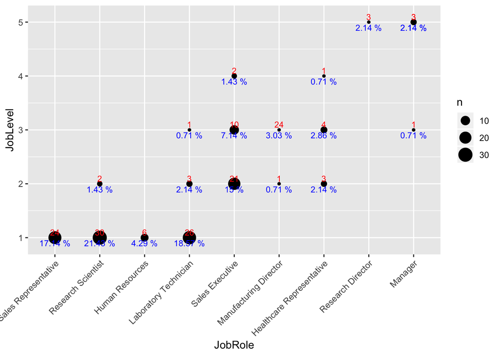

```r
attr_df %>%
  ggplot(aes(x=JobRole, y=JobLevel)) +
  geom_count(na.rm = TRUE) + scale_x_discrete(limits = ord) +
  geom_text(data = attr_count,
     aes(attr_count$JobRole,
       attr_count$JobLevel,
       label = attr_count_labels$n),
     size = 3,
     nudge_y = 0.1,
     color = 'red') +
  geom_text(data = attr_count,
     aes(attr_count$JobRole,
       attr_count$JobLevel,
       label = paste(attr_count_labels$prop, "%")),
     size = 3,
     nudge_y = -0.1,
     color = 'blue') +
  theme(axis.text.x = element_text(angle=45, hjust = 1))
```

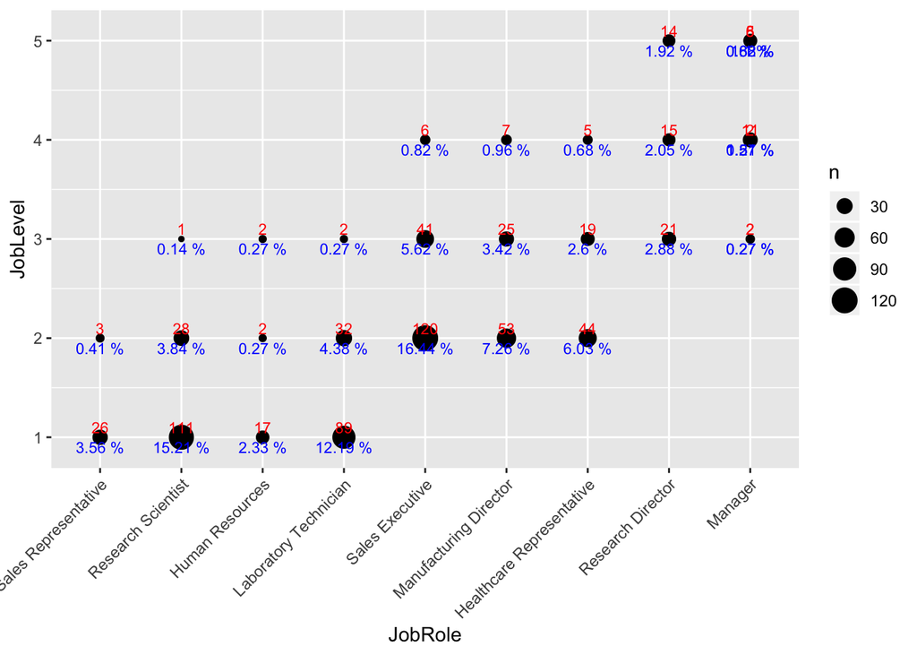

```r
nttr_df %>%
  ggplot(aes(x=JobRole, y=JobLevel)) +
  geom_count(na.rm = TRUE) + scale_x_discrete(limits = ord) +
  geom_text(data = nttr_count,
    aes(nttr_count$JobRole,
        nttr_count$JobLevel,
       label = nttr_count$n),
    size = 3,
    nudge_y = 0.1,
    color = 'red') +
  geom_text(data = nttr_count,
    aes(nttr_count$JobRole,
        nttr_count$JobLevel,
        label = paste(nttr_count$prop, "%")),
    size = 3,
    nudge_y = -0.1,
    color = 'blue') +
  theme(axis.text.x = element_text(angle=45, hjust = 1))
```

```r
set.seed(22)

fs_df <- cbind(raw_df[,2], raw_df[,4:36])

# Create dummy columns for categorical data

fs_df <- dummy_cols(fs_df)

# Remove categorical cols, replaced with dummies

f_df <- cbind(fs_df[,1],
              fs_df[,3],
              fs_df[,5:6],
              fs_df[,10],
              fs_df[,12],
              fs_df[,13:14],
              fs_df[,16],
              fs_df[,18:20],
              fs_df[,23:25],
              fs_df[,27:60],
              fs_df[,62:63])

lm_df <- f_df

# Fix names

names(f_df)[[1]] <- "Age"
names(f_df)[[2]] <- "DailyRate"
names(f_df)[[5]] <- "EnvironmentSatisfaction"
names(f_df)[[6]] <-  "HourlyRate"
names(f_df)[[9]] <- "JobSatisfaction"
```

```r
#~~~~~~~~~~~~~~~~Scaling features

cola <- c("DailyRate", "DistanceFromHome", "HourlyRate", "MonthlyIncome", "MonthlyRate",
          "PercentSalaryHike", "TotalWorkingYears", "YearsAtCompany", "YearsInCurrentRole",
          "YearsSinceLastPromotion", "YearsWithCurrManager")

all_scaled_df <- f_df %>% mutate_at(vars(cola), list(~scale(.) %>% as.vector))
```

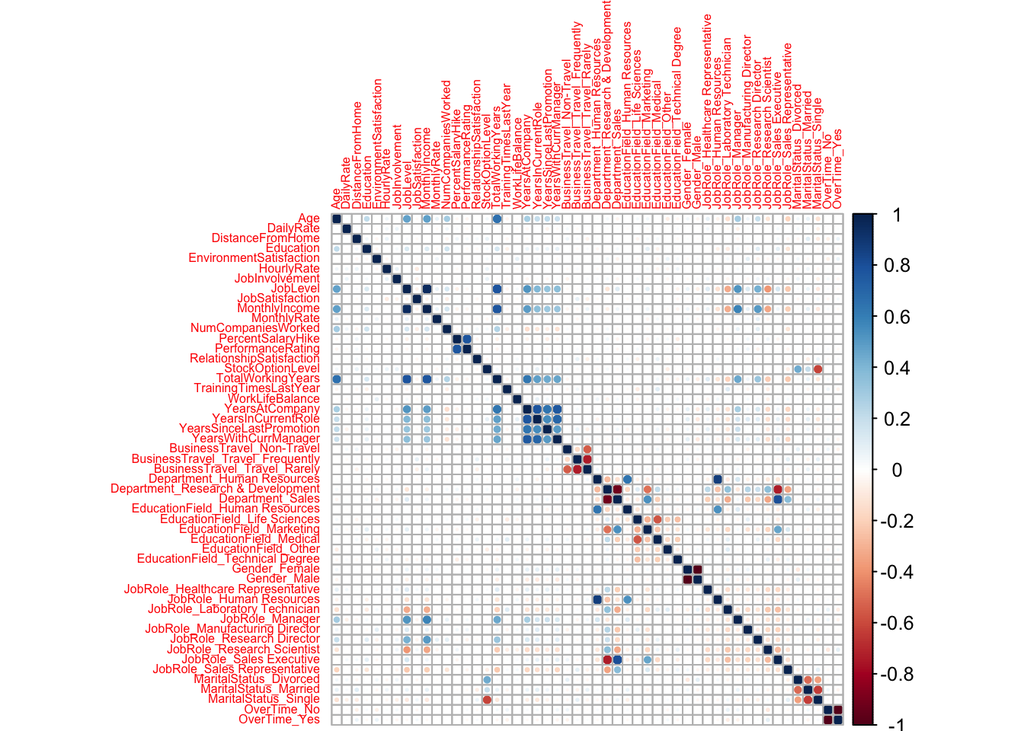

```r
#~~~~~~~~~~~~~~~~~~~~~~~Remove Redundant Features + Corrplot

correlationMatrix <- cor(all_scaled_df, use="pairwise.complete.obs")

corrplot(correlationMatrix, tl.cex = 0.5)
```

```r
# Search for the highly correlated features to remove for ML models

highlyCorrelated <- findCorrelation(correlationMatrix, cutoff = 0.75)

f_df <- all_scaled_df[,-(highlyCorrelated)]
```

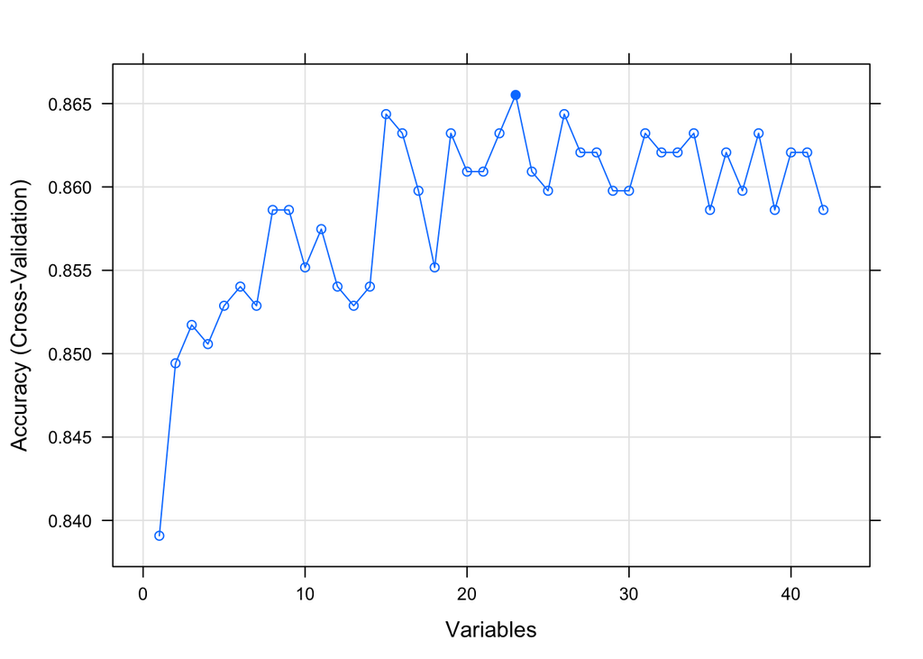

```r
#~~~~~~~~~~~~~~~~~~~~Feature Selection (Automatic)------LONG LOAD

control <- rfeControl(functions=rfFuncs, method="cv", number=10)

results <- rfe(f_df, raw_df[,3], sizes=c(1:42), rfeControl=control)

p_inx <- predictors(results)

pd_df <- all_scaled_df[,p_inx]

plot(results, type=c("g", "o"))
```

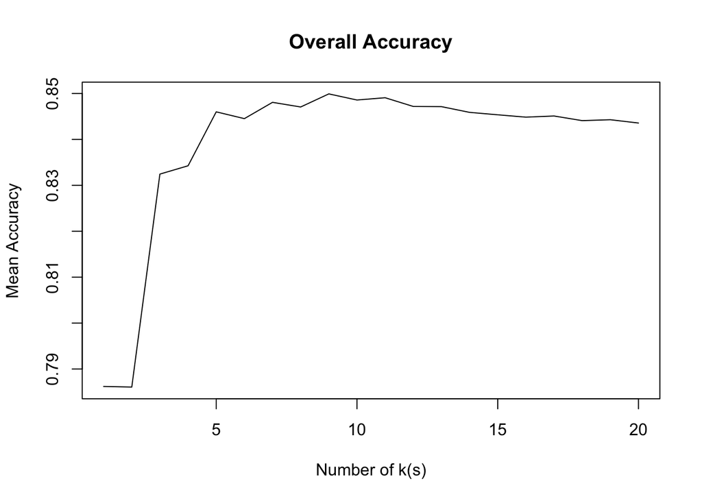

```r
set.seed(22)
iterations = 500
numks = 20
splitPerc = .7
masterAcc = matrix(nrow = iterations, ncol = numks)
masterSens = matrix(nrow = iterations, ncol = numks)
masterSpec = matrix(nrow = iterations, ncol = numks)
for(j in 1:iterations)
{
  k_inx = sample(1:dim(pd_df)[1],round(splitPerc * dim(pd_df)[1]))

  k_trn_data <- pd_df[k_inx,]

  k_tst_data <- pd_df[-k_inx,]

  #cl = raw_df[k_inx, 3]

  for(i in 1:numks)
  {
    classifications = knn(k_trn_data,
                          k_tst_data,
                          raw_df[k_inx, 3],
                          prob = TRUE, k = i)
    table(classifications,raw_df[-k_inx, 3])
    CM = confusionMatrix(table(classifications, raw_df[-k_inx, 3]))
    masterAcc[j,i] = CM$overall[1]
    masterSens[j,i] = CM$byClass[1]
    masterSpec[j,i] = CM$byClass[2]
  }

}

MeanAcc = colMeans(masterAcc)
plot(seq(1,numks,1),MeanAcc, type = "l", main = "Overall Accuracy", xlab = "Number of k(s)", ylab = "Mean Accuracy")
```

```r
which.max(MeanAcc)
```

```
## [1] 9
```

```r
max(MeanAcc)
```

```
## [1] 0.8499157
```

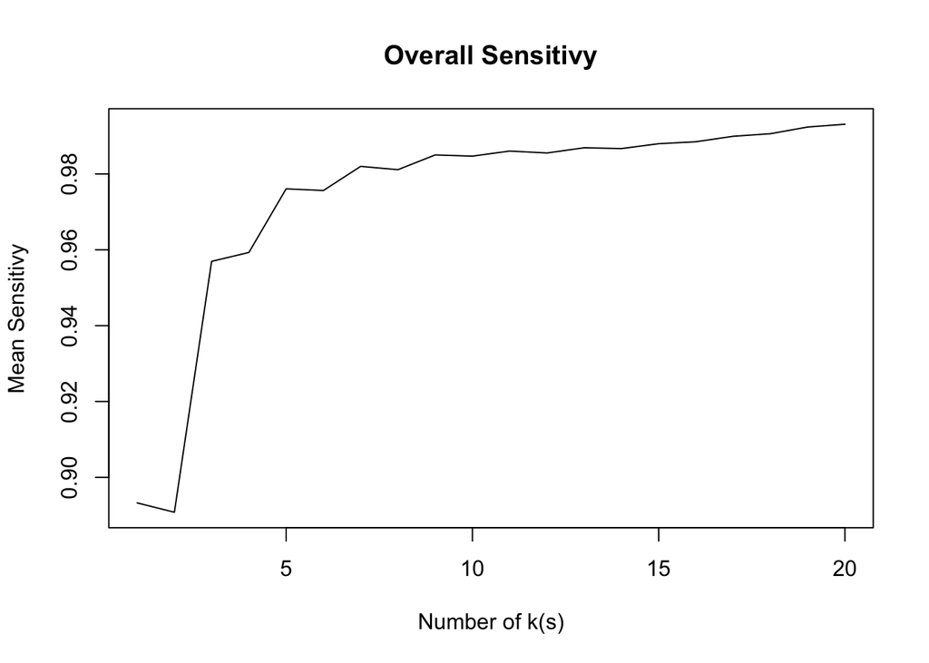

```r
MeanSens = colMeans(masterSens)
plot(seq(1,numks,1),MeanSens, type = "l", main = "Overall Sensitivy", xlab = "Number of k(s)", ylab = "Mean Sensitivy")
```

```r
which.max(MeanSens)
```

```
## [1] 20
```

```r
max(MeanSens)
```

```
## [1] 0.9930998
```

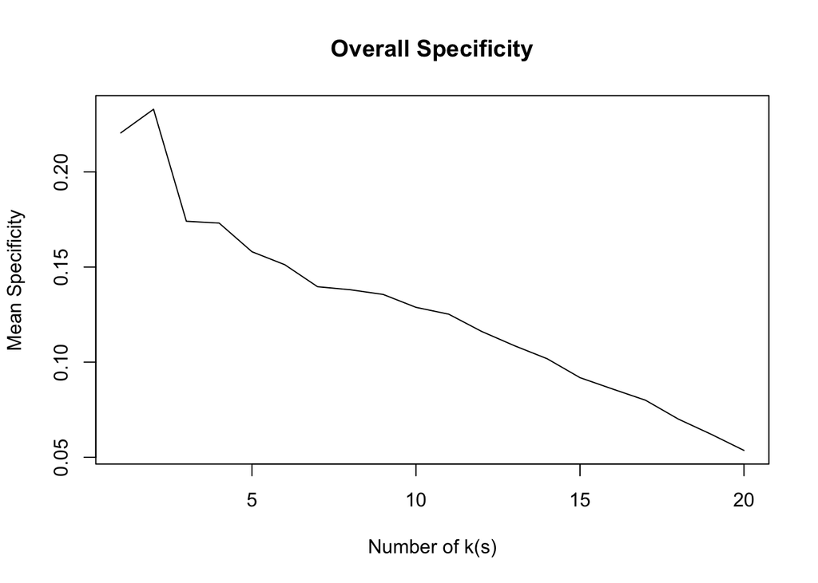

```r
MeanSpec = colMeans(masterSpec)
plot(seq(1,numks,1),MeanSpec, type = "l", main = "Overall Specificity", xlab = "Number of k(s)", ylab = "Mean Specificity")
```

```r
which.max(MeanSpec)
```

```
## [1] 2
```

```r
max(MeanSpec)
```

```
## [1] 0.2329392
```

```
## Will train until train_auc hasn't improved in 10 rounds.
##
## Stopping. Best iteration:
```

```
## Confusion Matrix and Statistics
##
##    x_test_labels
##       0   1
##   0 214  27
##   1   9  11
##
##                Accuracy : 0.8621
##                  95% CI : (0.8142, 0.9015)
##     No Information Rate : 0.8544
##     P-Value [Acc > NIR] : 0.403731
##
##                   Kappa : 0.31
##
##  Mcnemar's Test P-Value : 0.004607
##
##             Sensitivity : 0.9596
##             Specificity : 0.2895
##          Pos Pred Value : 0.8880
##          Neg Pred Value : 0.5500
##              Prevalence : 0.8544
##          Detection Rate : 0.8199
##    Detection Prevalence : 0.9234
##       Balanced Accuracy : 0.6246
##
##        'Positive' Class : 0
##
```

```
## [1] "test-auc= 0.137931034482759"
```

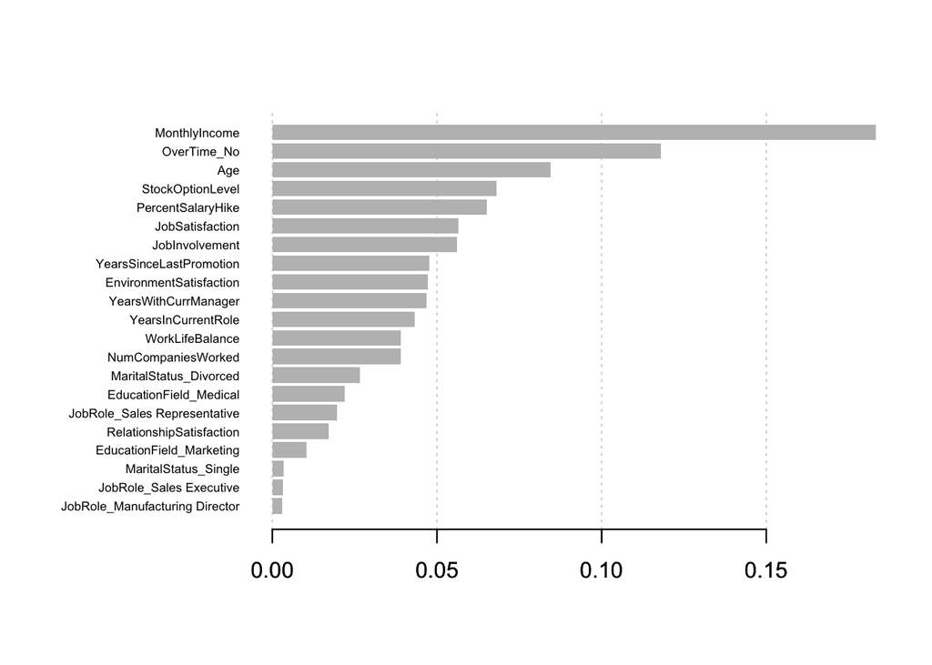

```
## [Tune] Started tuning learner classif.xgboost for parameter set:
```

```
##                      Type len Def          Constr Req Tunable Trafo
## booster          discrete   -   - gbtree,gblinear   -    TRUE     -
## max_depth         integer   -   -         3 to 10   -    TRUE     -
## min_child_weight  numeric   -   -         1 to 10   -    TRUE     -
## subsample         numeric   -   -        0.5 to 1   -    TRUE     -
## colsample_bytree  numeric   -   -        0.5 to 1   -    TRUE     -
```

```
## With control class: TuneControlRandom
```

```
## Imputation value: -0
```

```
## [Tune-x] 1: booster=gbtree; max_depth=8; min_child_weight=9.13; subsample=0.824; colsample_bytree=0.784
```

```
## [Tune-y] 1: acc.test.mean=0.8701851; time: 0.0 min
```

```
## [Tune-x] 2: booster=gblinear; max_depth=6; min_child_weight=9.26; subsample=0.754; colsample_bytree=0.558
```

```
## [Tune-y] 2: acc.test.mean=0.8719064; time: 0.0 min
```

```
## [Tune-x] 3: booster=gblinear; max_depth=10; min_child_weight=9.02; subsample=0.601; colsample_bytree=0.651
```

```
## [Tune-y] 3: acc.test.mean=0.8719064; time: 0.0 min
```

```
## [Tune-x] 4: booster=gbtree; max_depth=5; min_child_weight=5.43; subsample=0.546; colsample_bytree=0.503
```

```
## [Tune-y] 4: acc.test.mean=0.8768244; time: 0.0 min
```

```
## [Tune-x] 5: booster=gblinear; max_depth=3; min_child_weight=1.32; subsample=0.95; colsample_bytree=0.869
```

```
## [Tune-y] 5: acc.test.mean=0.8719064; time: 0.0 min
```

```
## [Tune-x] 6: booster=gblinear; max_depth=4; min_child_weight=1.83; subsample=0.644; colsample_bytree=0.58
```

```
## [Tune-y] 6: acc.test.mean=0.8719064; time: 0.0 min
```

```
## [Tune-x] 7: booster=gbtree; max_depth=3; min_child_weight=5.75; subsample=0.749; colsample_bytree=0.723
```

```
## [Tune-y] 7: acc.test.mean=0.8751304; time: 0.0 min
```

```
## [Tune-x] 8: booster=gblinear; max_depth=5; min_child_weight=9.06; subsample=0.927; colsample_bytree=1
```

```
## [Tune-y] 8: acc.test.mean=0.8719064; time: 0.0 min
```

```
## [Tune-x] 9: booster=gbtree; max_depth=3; min_child_weight=1.47; subsample=0.665; colsample_bytree=0.816
```

```
## [Tune-y] 9: acc.test.mean=0.8652397; time: 0.0 min
```

```
## [Tune-x] 10: booster=gbtree; max_depth=3; min_child_weight=1.56; subsample=0.76; colsample_bytree=0.842
```

```
## [Tune-y] 10: acc.test.mean=0.8767962; time: 0.0 min
```

```
## [Tune] Result: booster=gbtree; max_depth=5; min_child_weight=5.43; subsample=0.546; colsample_bytree=0.503 : acc.test.mean=0.8768244
```

```
## Confusion Matrix and Statistics
##
##           Reference
## Prediction   0   1
##          0 507  48
##          1   5  49
##
##                Accuracy : 0.913
##                  95% CI : (0.8877, 0.9341)
##     No Information Rate : 0.8407
##     P-Value [Acc > NIR] : 1.141e-07
##
##                   Kappa : 0.6039
##
##  Mcnemar's Test P-Value : 7.968e-09
##
##             Sensitivity : 0.9902
##             Specificity : 0.5052
##          Pos Pred Value : 0.9135
##          Neg Pred Value : 0.9074
##              Prevalence : 0.8407
##          Detection Rate : 0.8325
##    Detection Prevalence : 0.9113
##       Balanced Accuracy : 0.7477
##
##        'Positive' Class : 0
##
```

```
##         1
## 0.9081479
```

```
##        1
## 1392.628
```

```r
cm_sal_df <- read.csv("data/CaseStudy2CompSetNoSalary.csv")

sal_pred <- predict(fit, data.frame(JobLevel = cm_sal_df[,16], TotalWorkingYears = cm_sal_df[,29]))

submission_select <- data.frame(empID = cm_sal_df$ID, sal_pred = sal_pred)
write.csv(submission_select, file = 'sal_pred.csv', row.names = F)
```